# COVID-19 around the world

10/5/2021

## Index

- Introduction
- Methods
- Results
- Discussion
- Conclusion

## Introduction

For this project we merged data from two main sources: John Hopkins and Gapminder.

### John Hopkins data - [Repository Link](https://github.com/CSSEGISandData/COVID-19)

- Main datasets of the project
  - Time series of COVID-19 confirmed cases
  - Time series of COVID-19 deaths
  - Population count (IUD)

### Gapminder data - [Website Link](https://www.gapminder.org/data/)

- 18 datasets of varying relevance including:
  - Life expectancy
  - Smoking and Alcohol Consumption
  - Body Mass Index and Basic Sanitation

## Introduction

COVID-19 has impacted differently in different countries and the reasons why this has been the case are still under investigation.

In our project we aim to analyze a set of variables affecting mostly all countries to elucidate which may be the factors affecting COVID-19 outbreak.

To do this we performed an exploratory analysis using different datasets

## Methods

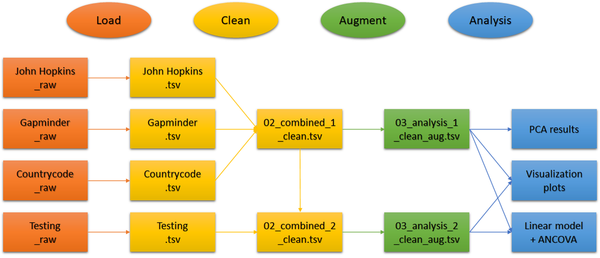

Worflow chart

## Methods

For the time series datasets we selected the Country/Region column and the number of cases reported the 29th April 2021.

The same procedure was appliad to dataset 02.

```
## # A tibble: 275 x 2
##    Country               Cases
##    <chr>                 <dbl>
##  1 Afghanistan           59576
##  2 Albania              130977
##  3 Algeria              121866
##  4 Andorra               13198
##  5 Angola                26431
##  6 Antigua and Barbuda    1232
##  7 Argentina           2954943
##  8 Armenia              215528
##  9 Australia               124
## 10 Australia              5477
## # … with 265 more rows
```

## Methods

For the rest of datasets we selected the country column and the most recent data (data from the last year registered).

```
##                    country Smoking
## 1                  Albania   0.224
## 2                  Algeria   0.152
## 3                  Andorra   0.329
## 4                Argentina   0.300
## 5                  Armenia   0.296
## 6                Australia   0.248
## 7                  Austria   0.433
## 8                  Bahrain   0.146
## 9               Bangladesh   0.256
## 10                Barbados   0.108
## 11                 Belarus   0.426
## 12                 Belgium   0.271
## 13                 Bolivia   0.317
## 14  Bosnia and Herzegovina   0.423
```

[output cut: 114 more lines]

Similar procedure for datasets 04 to 24.

## Methods

Then we grouped by country and sum the cases in the different regions of the same country.

```
## # A tibble: 192 x 2
##    Country               Cases
##    <chr>                 <dbl>
##  1 Afghanistan           59576
##  2 Albania              130977
##  3 Algeria              121866
##  4 Andorra               13198
##  5 Angola                26431
##  6 Antigua and Barbuda    1232
##  7 Argentina           2954943
##  8 Armenia              215528
##  9 Australia             29798
## 10 Austria              616739
## # … with 182 more rows
```

## Methods

### Main cleaning tasks

- Join John Hopkins data by Country column
- Join Gapminder data by Country column
- Remove NA in Gapminder data by replacing by the mean
- Fix country names so they look the same in both datasets
- Join both datasets

## Methods

We added the following new attributes to the dataset:

- Cases per 100000 inhabitants: \(\frac{Cases}{Population}100000\)
- Deaths per 100000 inhabitants: \(\frac{Deaths}{Population}100000\)
- Fatality rate: \(\frac{Deaths}{Cases}100\)
- Population density: \(\frac{Population}{Area}\)
- Fatality class
  - Low fatality
  - High fatality
- BMI class for both genders

## Methods

```
## # A tibble: 188 x 30
##    Country            Cases Deaths Population continent UrbanPop LifeExp Smoking
##    <chr>              <dbl>  <dbl>      <dbl> <chr>        <dbl>   <dbl>   <dbl>
##  1 Afghanistan       5.96e4   2618   38928341 Asia         0.258    63.4   0.247
##  2 Albania           1.31e5   2389    2877800 Europe       0.612    78.2   0.224
##  3 Algeria           1.22e5   3244   43851043 Africa       0.732    77.7   0.152
##  4 Andorra           1.32e4    125      77265 Europe       0.88     82.7   0.329
##  5 Angola            2.64e4    594   32866268 Africa       0.662    64.2   0.247
##  6 Antigua and Barb… 1.23e3     32      97928 Americas     0.245    77     0.247
##  7 Argentina         2.95e6  63508   45195777 Americas     0.92     76.7   0.3
##  8 Armenia           2.16e5   4087    2963234 Asia         0.632    75.6   0.296
##  9 Australia         2.98e4    910   25459700 Oceania      0.861    82.4   0.248
## 10 Austria           6.17e5  10179    9006400 Europe       0.585    81.8   0.433
## # … with 178 more rows, and 22 more variables: AlcConsump <dbl>, BMI_m <dbl>,
## #   BMI_f <dbl>, SBP_m <dbl>, SBP_f <dbl>, cholesterol_m <dbl>,
## #   cholesterol_f <dbl>, GovtHealthUSD_pp <dbl>, TotHealthUSD_pp <dbl>,
## #   LandSqkm <dbl>, DemScore <dbl>, CPI <dbl>, WomanInParlia <dbl>,
## #   Income_pp <dbl>, BasicSaniAcc <dbl>, Casesper100kpp <dbl>,
## #   Deathsper100kpp <dbl>, FatalityRate <dbl>, PopDens <dbl>,
## #   Fatality_class <chr>, BMI_m_class <chr>, BMI_f_class <chr>
```

## Data visualization

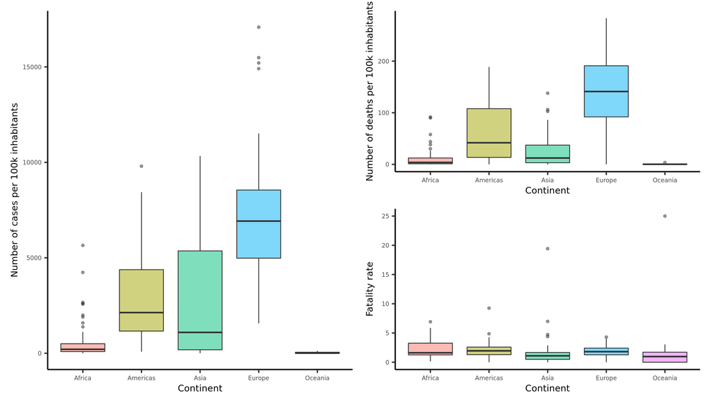

## Data visualization

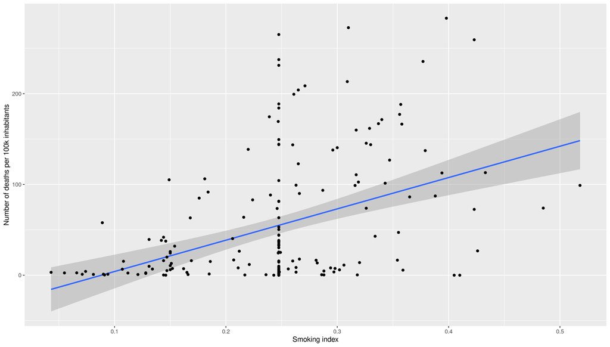

## Data visualization

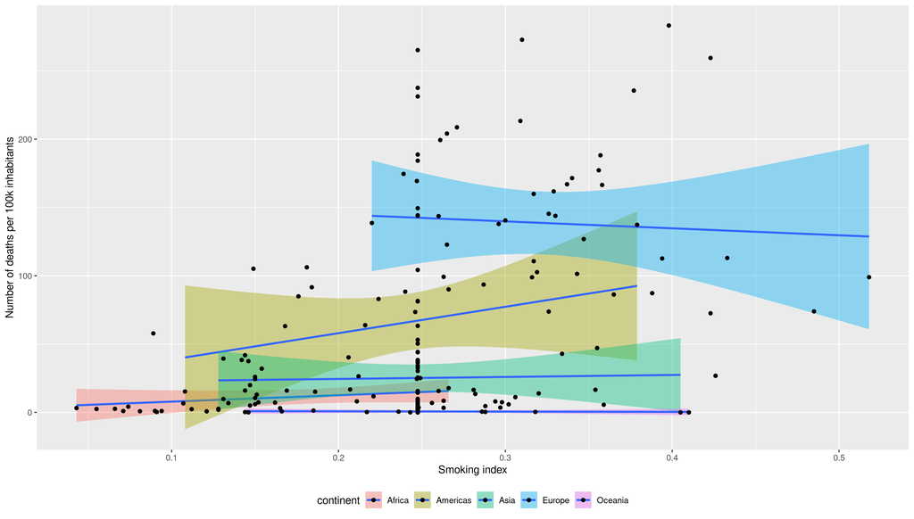

## Data visualization

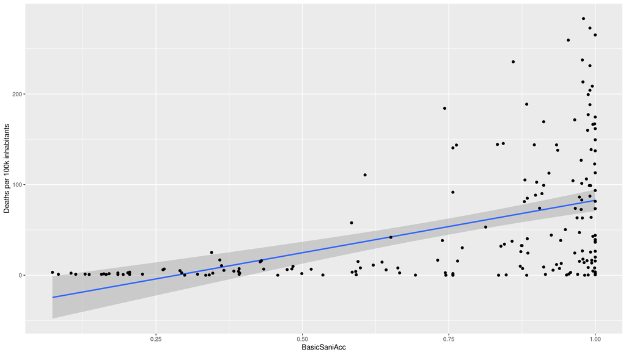

## Data visualization

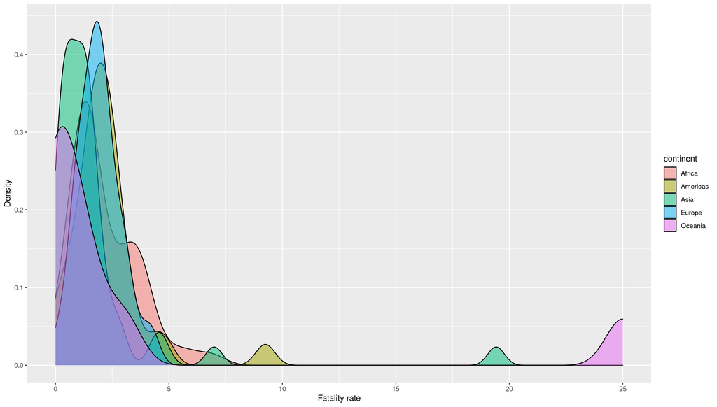

## Data visualization

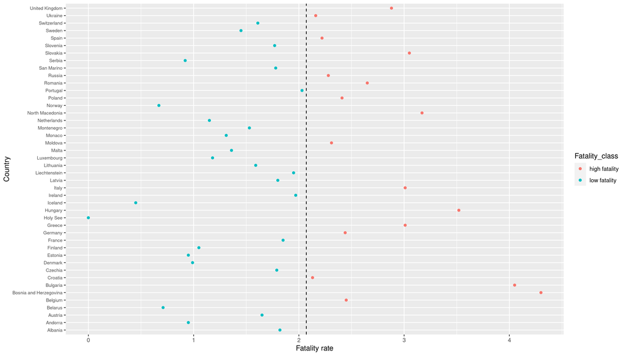

## PCA

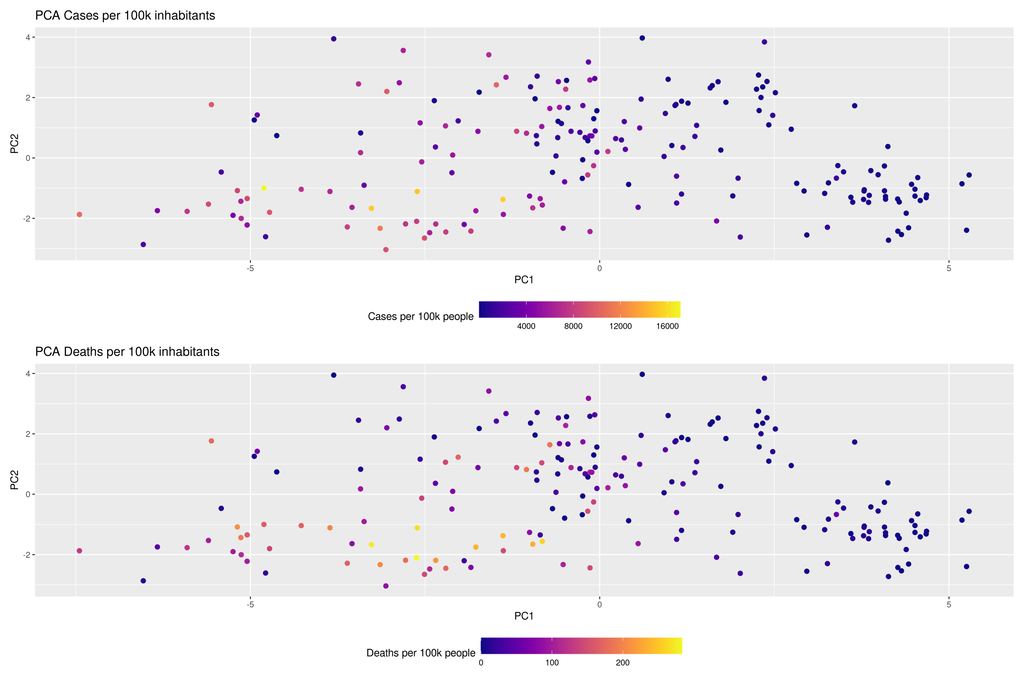

## Data visualization - Second analysis

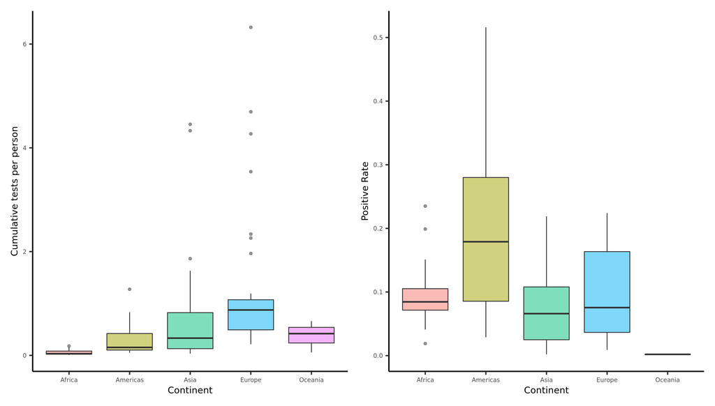

## Data visualization - Second analysis

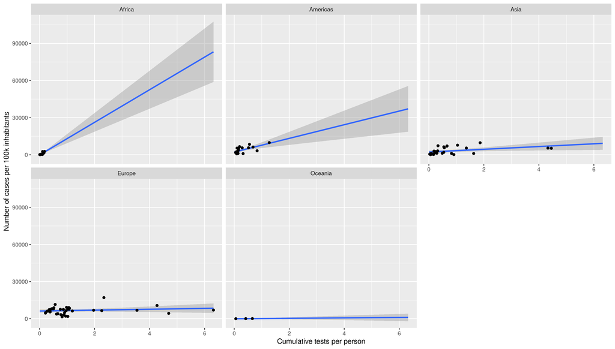

## Data visualization - Second analysis

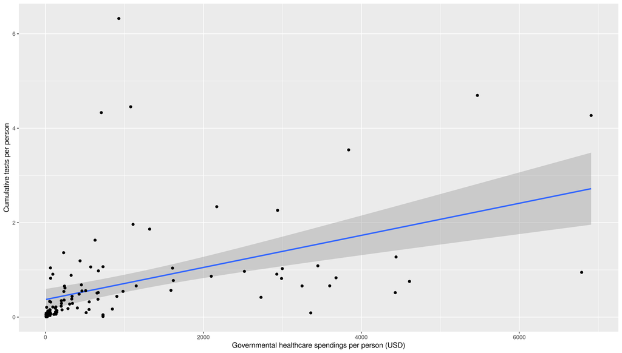

## Data visualization - Second analysis

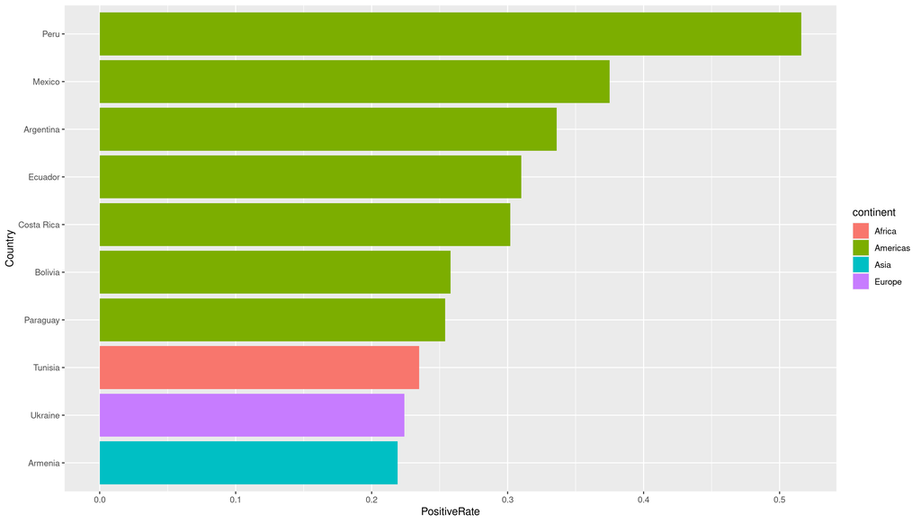

## Data visualization - Second analysis

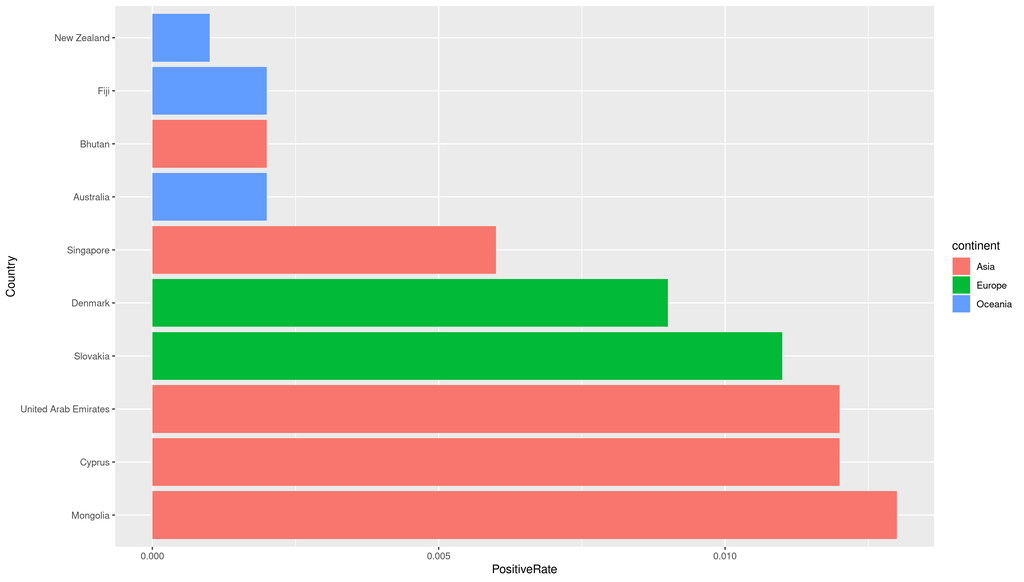

## Modelling

### 4 different y variables

- Cases per 100k persons, Deaths per 100k persons, Fatality rate (Deaths/Cases), Positive rate (Cases/Tests)

### 19 different x variables:

- Continent, % of urban population, % of smoking adults, blood pressure, Cholesterol levels, BMI, etc.

For each of the y variables we fitted a linear model without any interaction terms. Because we had categorical variables, we then a ancova to identify the significant attributes (alpha=0.05).

## Data analysis

```
## # A tibble: 10 x 5
##    variable  p.value_Casespe… p.value_Deathsp… p.value_Fatalit… p.value_Positiv…
##    <chr>                <dbl>            <dbl>            <dbl>            <dbl>
##  1 continent       0.00000145         5.87e-10          NA               0.00321
##  2 UrbanPop        0.0388            NA                 NA              NA
##  3 choleste…       0.0472             9.27e- 3          NA              NA
##  4 choleste…       0.0324             2.19e- 2          NA              NA
##  5 DemScore        0.0441             2.81e- 3          NA              NA
##  6 SBP_m          NA                  3.99e- 3          NA              NA
##  7 SBP_f          NA                  1.19e- 2          NA               0.0270
##  8 CPI            NA                  4.57e- 2          NA               0.00841
##  9 BasicSan…      NA                 NA                  0.0226         NA
## 10 LifeExp        NA                 NA                 NA               0.0318
```

## Model limitations

### Further ideas:

- Check for outliers
- Check if model assumptions are fullfilled
- Include interaction terms
- Use backward/forward term selection to reduce the models

## Conclusions

It seems that the number of cases and deaths are not really informative about the situation in some countries because the testing rate differs among them.

Even when including the testing rate in our analysis it seems that the way this procedure is performed among the countries is very different and that differences should also be taken into account in future analyses (look into metadata about how the testing is carried out in the different countries)